# Predicting Grasshopper Sparrow Abundance by Landscape Characteristics

Daniel Redwine

2023-10-04

# Grasshopper Sparrow Abundance

Grasshopper Sparrows are a grassland obligate species with a distribution across much of the continental United States. Using a dataset obtained from Dryad [here](https://doi.org/10.5061/dryad.9pr1476), we will model Grasshopper Sparrow abundance based on landscape characteristics.

[interactive chart not shown]

Figure 1. Photograph of a Grasshopper Sparrow

# Visualizing Abundance Data

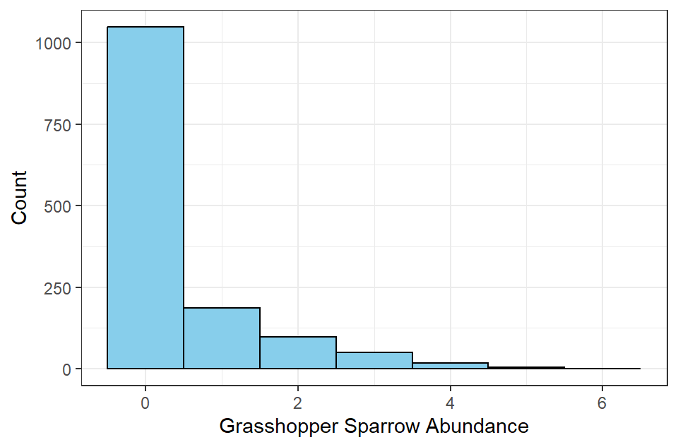

Figure 2. Histogram showing counts of different grasshopper sparrow abundances

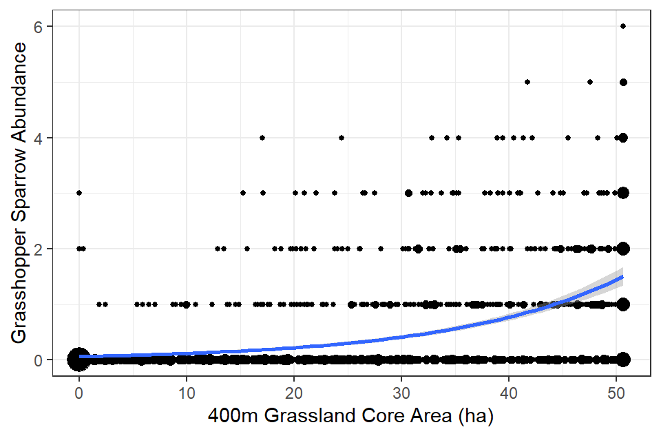

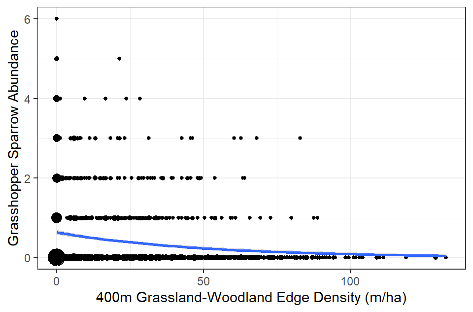

Figure 3. Plots showing the relationship between 400m grassland core area (ha) and Grasshopper Sparrow abundance (left) and 400m grassland-woodland edge density (m/ha) and Grasshopper Sparrow abundance (right).

We can see a positive relationship between grassland core area and Grasshopper Sparrow counts and a negative relationship between grassland-woodland edge density (m/ha) at the 400m scale. Looks like there may be a large amount of zeros in the dataset possibly skewing the data, but we’ll check Poisson model output.

# Poisson GLM

A Poisson GLM showing the relationships between Grasshopper Sparrow counts and both 400m grassland core area (ha) and 400m grassland-woodland edge density (m/ha).

```
##
## Call:
## glm(formula = grsp ~ ca_400 * grass_tree_ed_400, family = poisson,
##     data = grsp_abundance_data_clean)
##
## Coefficients:
##                            Estimate Std. Error z value Pr(>|z|)
## (Intercept)              -2.3627051  0.1591911 -14.842  < 2e-16 ***
## ca_400                    0.0541018  0.0037823  14.304  < 2e-16 ***
## grass_tree_ed_400        -0.0195820  0.0064892  -3.018  0.00255 **
## ca_400:grass_tree_ed_400  0.0004486  0.0002093   2.143  0.03212 *
## ---
## Signif. codes:  0 '***' 0.001 '**' 0.01 '*' 0.05 '.' 0.1 ' ' 1
##
## (Dispersion parameter for poisson family taken to be 1)
##
##     Null deviance: 1892.4  on 1403  degrees of freedom
## Residual deviance: 1367.9  on 1400  degrees of freedom
## AIC: 2229.8
##
## Number of Fisher Scoring iterations: 6
```

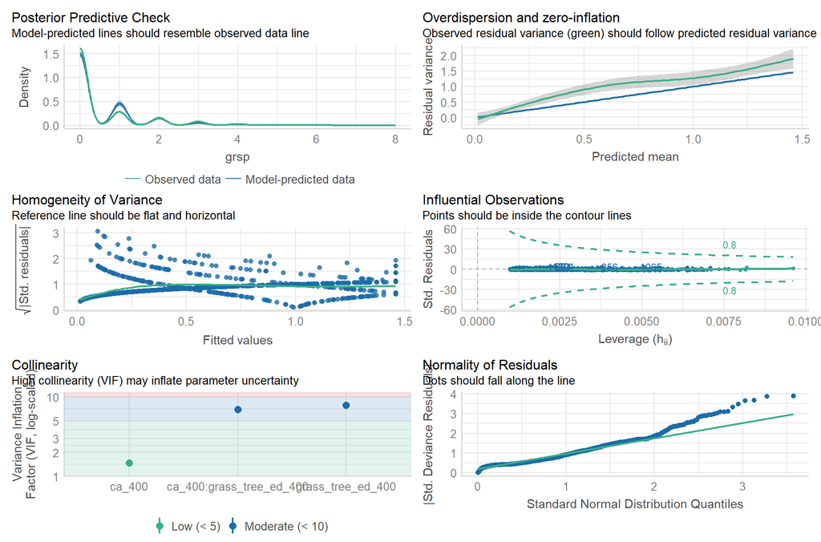

Figure 4. Assumptions of Poisson model including all data. Observed is close to predicted in most cases.

We could also run a quasipoisson to see if this helps with any of the assumptions.

```
##
## Call:
## glm(formula = grsp ~ ca_400 * grass_tree_ed_400, family = quasipoisson,
##     data = grsp_abundance_data_clean)
##
## Coefficients:
##                            Estimate Std. Error t value Pr(>|t|)
## (Intercept)              -2.3627051  0.1910935 -12.364   <2e-16 ***
## ca_400                    0.0541018  0.0045403  11.916   <2e-16 ***
## grass_tree_ed_400        -0.0195820  0.0077897  -2.514   0.0121 *
## ca_400:grass_tree_ed_400  0.0004486  0.0002513   1.785   0.0744 .
## ---
## Signif. codes:  0 '***' 0.001 '**' 0.01 '*' 0.05 '.' 0.1 ' ' 1
##
## (Dispersion parameter for quasipoisson family taken to be 1.440968)
##
##     Null deviance: 1892.4  on 1403  degrees of freedom
## Residual deviance: 1367.9  on 1400  degrees of freedom
## AIC: NA
##
## Number of Fisher Scoring iterations: 6
```

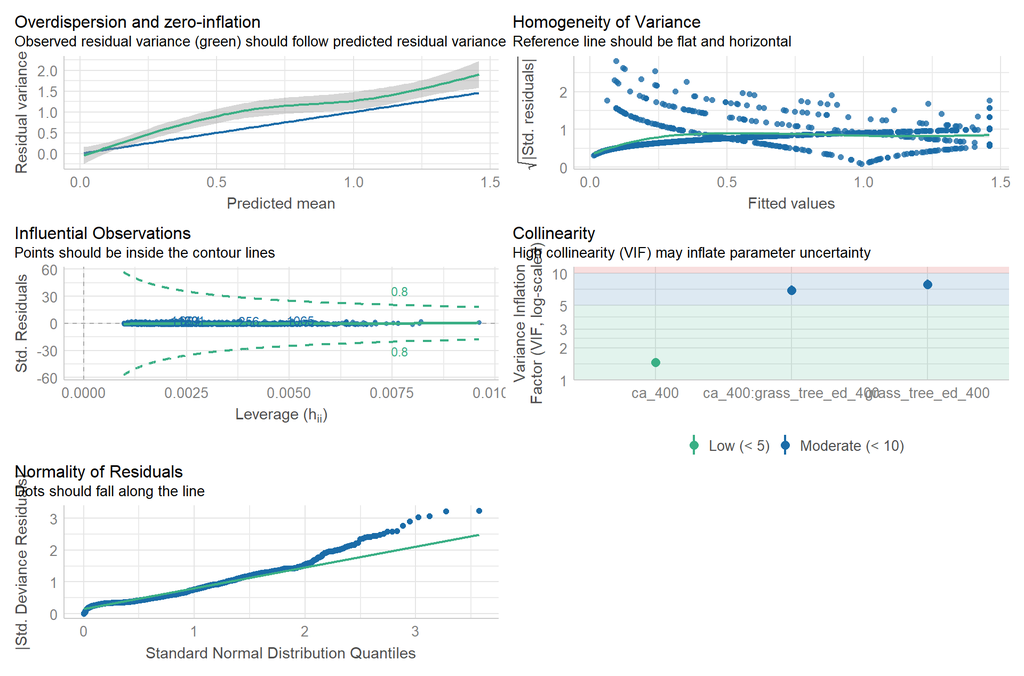

Figure 5. Assumptions of quasiPoisson model including all data. Output is similar to the Poisson model.

We don’t see an improvement with any of these parameters for the quasipoisson model. For model interpretation we will use the Poisson GLM.

# Model Interpretation

```
##
## Call:
## glm(formula = grsp ~ ca_400 * grass_tree_ed_400, family = poisson,
##     data = grsp_abundance_data_clean)
##
## Coefficients:
##                            Estimate Std. Error z value Pr(>|z|)
## (Intercept)              -2.3627051  0.1591911 -14.842  < 2e-16 ***
## ca_400                    0.0541018  0.0037823  14.304  < 2e-16 ***
## grass_tree_ed_400        -0.0195820  0.0064892  -3.018  0.00255 **
## ca_400:grass_tree_ed_400  0.0004486  0.0002093   2.143  0.03212 *
## ---
## Signif. codes:  0 '***' 0.001 '**' 0.01 '*' 0.05 '.' 0.1 ' ' 1
##
## (Dispersion parameter for poisson family taken to be 1)
##
##     Null deviance: 1892.4  on 1403  degrees of freedom
## Residual deviance: 1367.9  on 1400  degrees of freedom
## AIC: 2229.8
##
## Number of Fisher Scoring iterations: 6
```

```
##                                  2.5 %        97.5 %
## (Intercept)              -2.683862e+00 -2.0595080728
## ca_400                    4.682001e-02  0.0616546843
## grass_tree_ed_400        -3.286141e-02 -0.0074090788
## ca_400:grass_tree_ed_400  4.963996e-05  0.0008707618
```

We can see that the confidence intervals for both predictors and the interaction term do not cross zero indicating that they are significant.

```
##              (Intercept)                   ca_400        grass_tree_ed_400
##            -2.3627050524             0.0541018157            -0.0195820315
## ca_400:grass_tree_ed_400
##             0.0004486105
```

Here we can see the coefficients for the predicted lines. For the logit transformation e^(coef*x) is the transformation which occurs. There is a positive coefficient for grassland core area at the 400m scale. Therefore the predicted abundance of Grasshopper Sparrow increases at a rate of e^0.054x for each hectare of grassland core area within 400m. Grassland and woodland edge density (m/ha) has a negative coefficient, so Grasshopper Sparrow abundance decreases at a rate of e^-0.020x for each additional meter of grassland-woodland edge per hectare within 400m. However, we cannot use these terms to directly extrapolate density because there is an interaction between grassland-woodland edge and grassland core area.

# Hurdle Model

To see if correction for zero-inflation improves the model, we will model presence/absence and nonzero counts separately. A hurdle model assumes that there is some “hurdle” that must be overcome before an event occurs. Since we are using the same few factors for both the binomial and the Poisson GLM, we may not be meeting this assumption. The ZIP model may be a better fit for this data.

## Binomial Model

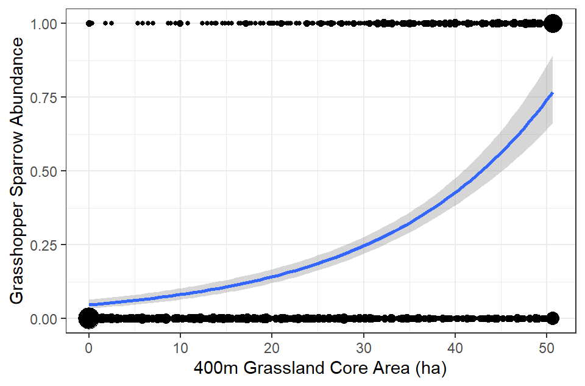

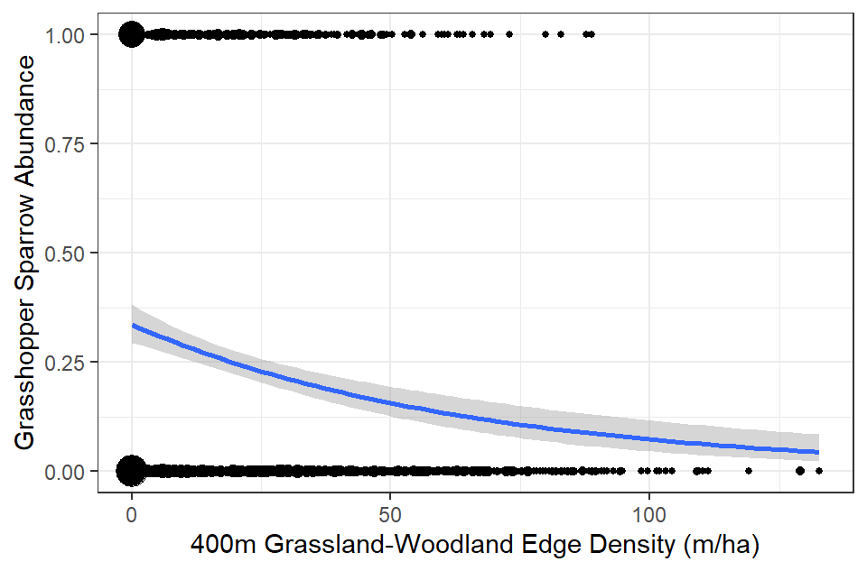

Figure 6. Plots showing the relationship between 400m grassland core area (ha) and Grasshopper Sparrow presence (left) and 400m grassland-woodland edge density (m/ha) and Grasshopper Sparrow presence (right).

```
##
## Call:
## glm(formula = grsp ~ ca_400 * grass_tree_ed_400, family = binomial(link = "logit"),
##     data = grsp_abundance_binary_data)
##
## Coefficients:
##                            Estimate Std. Error z value Pr(>|z|)
## (Intercept)              -2.9257691  0.2287009 -12.793   <2e-16 ***
## ca_400                    0.0711865  0.0062375  11.413   <2e-16 ***
## grass_tree_ed_400        -0.0204435  0.0091503  -2.234   0.0255 *
## ca_400:grass_tree_ed_400  0.0004757  0.0003242   1.467   0.1423
## ---
## Signif. codes:  0 '***' 0.001 '**' 0.01 '*' 0.05 '.' 0.1 ' ' 1
##
## (Dispersion parameter for binomial family taken to be 1)
##
##     Null deviance: 1592.1  on 1403  degrees of freedom
## Residual deviance: 1254.3  on 1400  degrees of freedom
## AIC: 1262.3
##
## Number of Fisher Scoring iterations: 5
```

```
##                                  2.5 %       97.5 %
## (Intercept)              -3.3899371875 -2.492514754
## ca_400                    0.0592489378  0.083720662
## grass_tree_ed_400        -0.0393569418 -0.003445580
## ca_400:grass_tree_ed_400 -0.0001386077  0.001133791
```

```
##              (Intercept)                   ca_400        grass_tree_ed_400
##            -2.9257691132             0.0711865464            -0.0204435472
## ca_400:grass_tree_ed_400
##             0.0004757184
```

For presence we can see that both 400m core area and grassland-woodland edge density are significant predictors of Grasshopper Sparrow presence, but the interaction term is not. Confidence intervals for significant terms do not cross zero. Positive coefficient for core area, negative for grassland-woodland edge density.

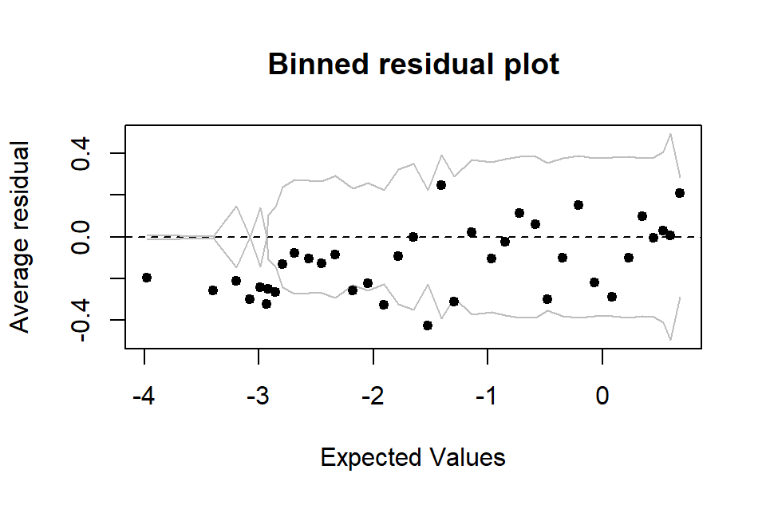

Figure 7. Checking overdispersion of data. Note that some points fall outside the 95% CI

## Non-zero Poisson

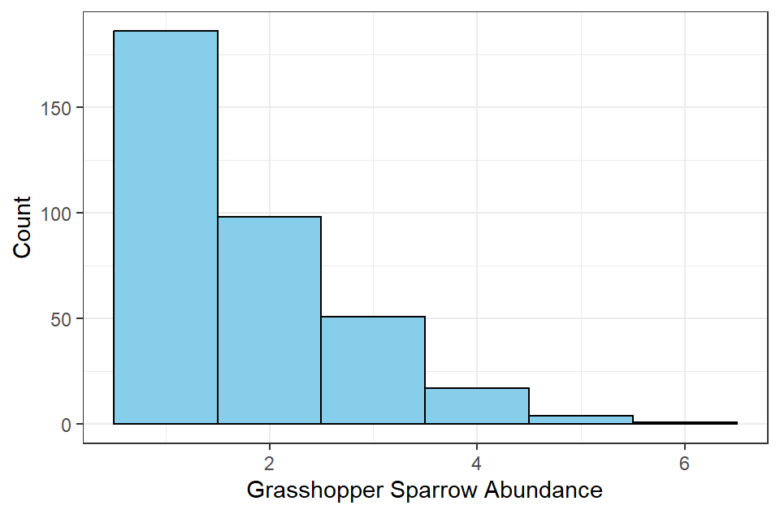

Figure 8. Histogram showing nonzero counts of different grasshopper sparrow abundances

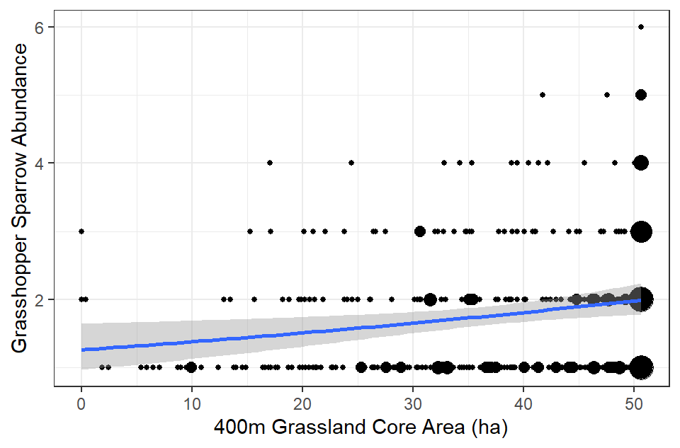

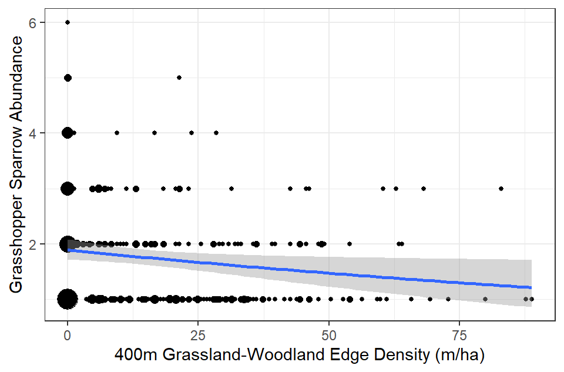

Figure 9. Plots showing the relationship between 400m grassland core area (ha) and Grasshopper Sparrow abundance (left) and 400m grassland-woodland edge density (m/ha) and Grasshopper Sparrow abundance (right) for nonzero data.

```
##
## Call:
## glm(formula = grsp ~ ca_400 * grass_tree_ed_400, family = poisson,
##     data = grsp_abundance_nonzero_data)
##
## Coefficients:
##                            Estimate Std. Error z value Pr(>|z|)
## (Intercept)               0.2986804  0.1702652   1.754   0.0794 .
## ca_400                    0.0085575  0.0040731   2.101   0.0356 *
## grass_tree_ed_400         0.0022793  0.0073655   0.309   0.7570
## ca_400:grass_tree_ed_400 -0.0001884  0.0002375  -0.793   0.4276
## ---
## Signif. codes:  0 '***' 0.001 '**' 0.01 '*' 0.05 '.' 0.1 ' ' 1
##
## (Dispersion parameter for poisson family taken to be 1)
##
##     Null deviance: 169.78  on 356  degrees of freedom
## Residual deviance: 160.07  on 353  degrees of freedom
## AIC: 1021.9
##
## Number of Fisher Scoring iterations: 4
```

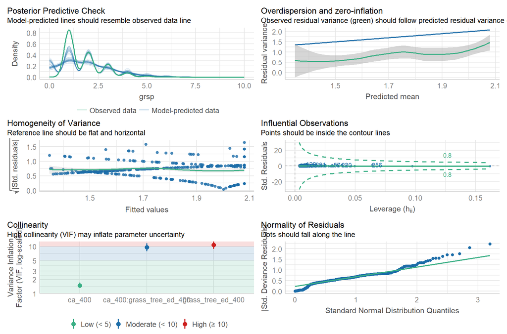

Figure 10. Assumptions of nonzero Poisson model. Some of these look worse than the original Poisson

It seems that this model is not a better fit than the original Poisson Model. An additional technique would be to utilize a ZIP model, but for now we’ll stick with the original Poisson model.